# Investigating Pre and Post-Pandemic Publication Trends in the Humanities and Medicine

STA3100 Final Project

Anjali Tomerlin and Elena Peden

2025-12-03

# Abstract

Academic research contains a variety of fields including but not limited to natural sciences and the humanities. After the pandemic in 2020, prioritization of research redirected to disproportionately emphasize the medical field. The long-term impact of this shift away from the humanities has gone largely unexplored. This study uses annual publication counts on OpenAlex from the past 25 years to examine the trends in medical research versus research in the humanities, defined as history, philosophy, art, and literature. Initial analysis showed a consistent increase in published works across all fields up until the year 2020. In 2021, the humanities revealed a sharp decline, while medicine only fell off moderately after a positive spike in 2020. An interrupted time-series analysis via segmented linear regressions with a structural break at 2020 for each field produced excellent fits (adjusted $\small r^2 > 0.90$ across fields). Multiple Chow’s Tests conducted using the aforementioned segmented linear regressions confirmed statistically significant structural breaks at 2020 in all five fields ($\small p < 0.001$). Consistently, there has been a much stronger emphasis on research in medicine over the humanities and the trends after 2020 are only increasing the disproportion. These findings underscore the need for a stronger emphasis on research in the humanities.

# Introduction & Motivation

Immediately following the advent of the COVID-19 pandemic in 2020, the focus of much academic research and funding pivoted towards the medicine and public health sectors. However, the long-term impact of this shift in the prevalence of research in other areas, particularly the humanities, has been overlooked. Our study is motivated by the lack of available information and analysis on this topic, despite it being one of great importance. Though often disregarded by those in STEM-related fields, research in the humanities is necessary as it fosters critical thinking, empathy, and a greater understanding of human society and culture.

A 2021 study investigated the effect the COVID-19 pandemic had on the production of medicine research and found an estimated 18% decrease in non-COVID-19 related published works. [1] However, no prior studies have conducted a comprehensive review of the pandemic’s effect on the production of research in the humanities. We expected to find a similar trend for humanities publications as was found for non-COVID-19 related published works.

## Objectives

Five years after the initial COVID-19 outbreak, we aim to compare generally the annual number of published works in the humanities with those in medicine. Additionally, we aim to narrow our investigation to analyze pre- and post-pandemic trends in the annual number of published works between those fields, defining humanities independently as history, philosophy, art, and literature. Our analysis highlights any potential difference in research productivity between fields or patterns of decline in research pre and post-pandemic. By doing so, we hope to call attention to the importance of the humanities and, more broadly, research in academia.

# Data & Exploratory Analysis

The data sets used in our project were sourced from OpenAlex, an open-source catalog of scholarly works. OpenAlex categorizes works using a hierarchical structure known as *concepts*. There are 19 root-level concepts, which represent broad categories of research such as Engineering and History, and 6 branching layers of concepts, each increasing in topic specificity. [2]

We utilized OpenAlex’s data sets for the annual number of published works whose concept classifiers are history, [3] philosophy, [4] art, [5] literature, [6] and medicine. [7] All of these fall into level 0 of the concept hierarchy (the most broad category) except for literature which is slightly more specific at level 1. Although each of these OpenAlex data sets have values dating back to 1826, our analysis only considered those from years 2000 to 2024 for relevancy and to avoid inaccuracies associated with pre-internet era records.

## Trend Evaluation

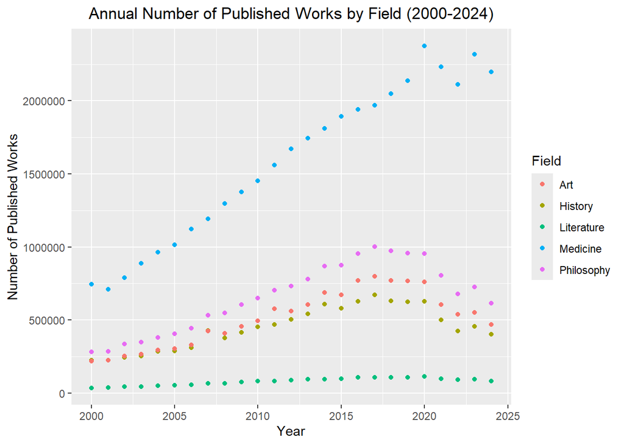

It is clear from the scatter plot above that all four humanities-related fields—history, philosophy, art, and literature—displayed an increasing trend in annual number of published works from 2000 to 2020 and a decreasing trend thereafter.

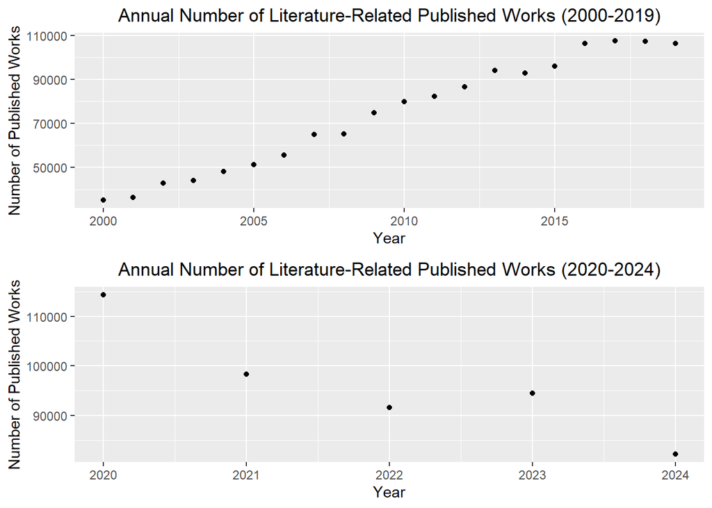

However, medicine deviated from this course as it displayed a clear upward trend in the annual number of published works from 2000 to 2020 but exhibited no immediately apparent pattern thereafter. Additionally, is should be noted that the number of medicine-related works spiked in 2020. It can be reasonably presume this was due to the increased medical research conducted to address the emerging pandemic.

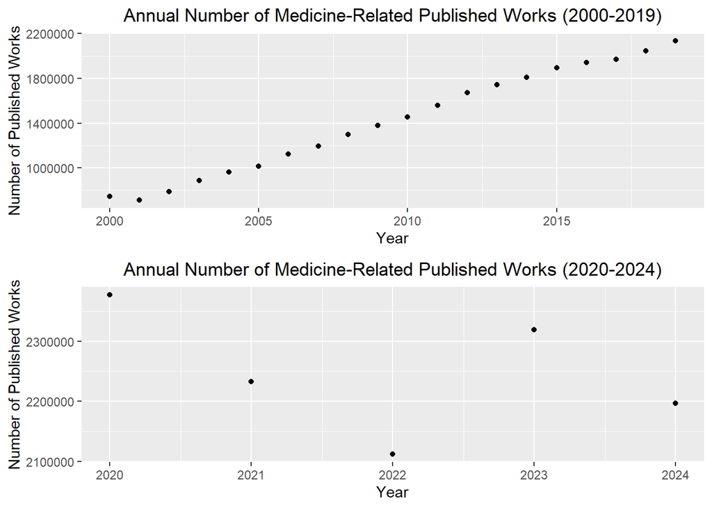

These trends suggest that, following the pandemic in 2020, there was a decline in emphasis on the funding and publishing of humanities-related research. However, the decline in emphasis on research in the medical field was less substantive, resulting in relative stability for medicine published works as opposed to the previous growth. However, further analysis was required to establish this (See Analysis & Results).

## Comparing Fields

The average annual number of medicine-related published works exceeded the average annual number of published works across all four humanities-related fields aggregated together from 2000 to 2024 by 1159384. This was true even for years prior to 2020, with a difference of 1007079, indicating that medicine was a consistently more productive field of research than those in the humanities even prior to the pandemic.

Additionally, the average annual number of published works from 2000 to 2024 varied much more between medicine and the humanities than between the humanities fields themselves. This indicates that fields in the humanities receive a similar amount of research attention when compared to medicine, which attracts much more research focus and produces substantially more publications every year.

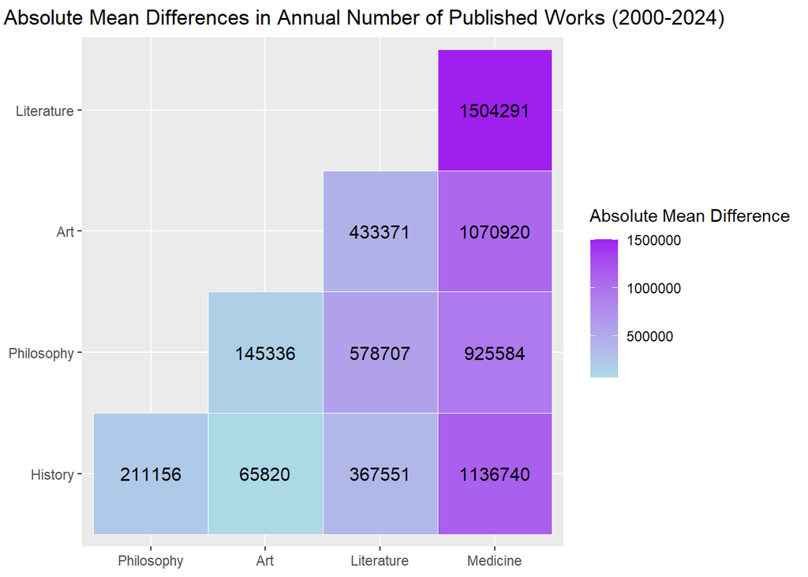

In comparing the data independently of a line of best fit, the variation in annual number of published works from 2000 to 2024 was much higher for medicine than the humanities-related fields. This was to be expected as a steeper positive trend in publication output will result in a more substantial change over time.

| Field | Standard Deviation |
| --- | --- |
| Literature | 24902 |
| History | 144074 |
| Art | 190457 |
| Philosophy | 234793 |
| Medicine | 541190 |

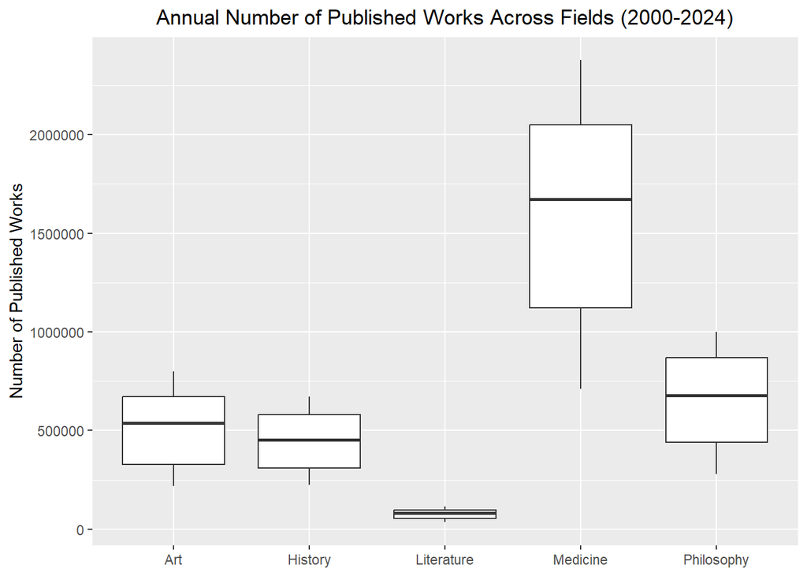

# Analysis & Results

Our primary analysis consisted of two procedures:

1. Conduct an interrupted time-series (ITS) analysis on the annual number of published works before and after the onset of the COVID-19 pandemic in 2020 for each of the five research fields—history, philosophy, art, literature, and medicine—using multiple segmented linear regressions.
2. Performing Chow’s Test to evaluate whether the COVID-19 pandemic in 2020 corresponded to a statistically significant shift in the parameters of the previously constructed segmented linear regressions.

## ITS Analysis

The data for each of the five research fields was split into two groups: data prior to and at the start of the COVID-19 pandemic (years 2000 to 2020), and after the pandemic’s initial outbreak (years 2021 to 2024). Five segmented linear regressions were constructed, each with a singular structural break point at the year 2020. This resulted in five separate piecewise functions for each field with an independent variable $\small t$, measured in years since 2000, and dependent variable $\small \hat{y}(t)$, the estimated number of works published in that field at corresponding year $\small t$.

The segmented linear regression model constructs separate linear models using the method of ordinary least squares for points before and after a number of specified break points while ensuring continuity between regression segments at the break point. For each field, we constructed a segmented linear regression with a singular break point at the year 2020, which resulted in two separate linear regression functions for $\small t\leq20$ and $\small t>20$ that meet at $\small t=20$ exactly. A segmented linear regression model for the number of works $\small Y_i$ published at time $\small t_i$, measured in years since 2000 is formulated as follows:

$$Y_i=\beta_0+\beta_1t_i+\beta_2(t_i-20)^++\epsilon_i$$

- $\small \beta_0$: Regression intercept for first linear segment ($\small t_i\leq20$)
- $\small \beta_1$: Regression slope for first linear segment ($\small t_i\leq20$)
- $\small \beta_2$: Change in regression slope for second linear segment compared to the first
- $\small (t_i-20)^+$: Piecewise function where $\small (t_i-20)^+=t_i-20$ if $\small t_i>20$ and $\small (t_i-20)^+=0$ if $\small t_i\leq20$
- $\small \epsilon_i$: Error term

Alternatively, the model can be formulated as the following piecewise function:

$$Y_i=\begin{cases}
\beta_0+\beta_1t_i+\epsilon_i &\text{if } t \leq 20 \\
(\beta_0-20\beta_2)+(\beta_1+\beta_2)t_i+\epsilon_i &\text{if } t
> 20 \end{cases}$$

We utilized this formulation as we went forward. From this model, the following regression with estimated coefficients was calculated for each of the fields:

$$\hat{y}(t)=\begin{cases} a_1 + b_1t&
\text{if } t \leq 20 \\ a_2 + b_2t & \text{if } t > 20
\end{cases}$$

- $\small a_1=\hat{\beta_0}$
- $\small b_1=\hat{\beta_1}$
- $\small a_2=\hat{\beta_0}-20\hat{\beta_2}$
- $\small b_2=\hat{\beta_1}+\hat{\beta_2}$

The following table reports the regression parameter estimates for each of the five constructed segmented linear regressions:

|  | a<sub>1</sub> | b<sub>1</sub> | a<sub>2</sub> | b<sub>2</sub> |
| --- | --- | --- | --- | --- |
| History | 208001 | 23295 | 2292992 | -80955 |
| Philosophy | 253992 | 38773 | 3367697 | -116912 |
| Art | 187312 | 31326 | 2765792 | -97598 |
| Literature | 34335 | 4099 | 296094 | -8989 |
| Medicine | 655342 | 80441 | 2558101 | -14697 |

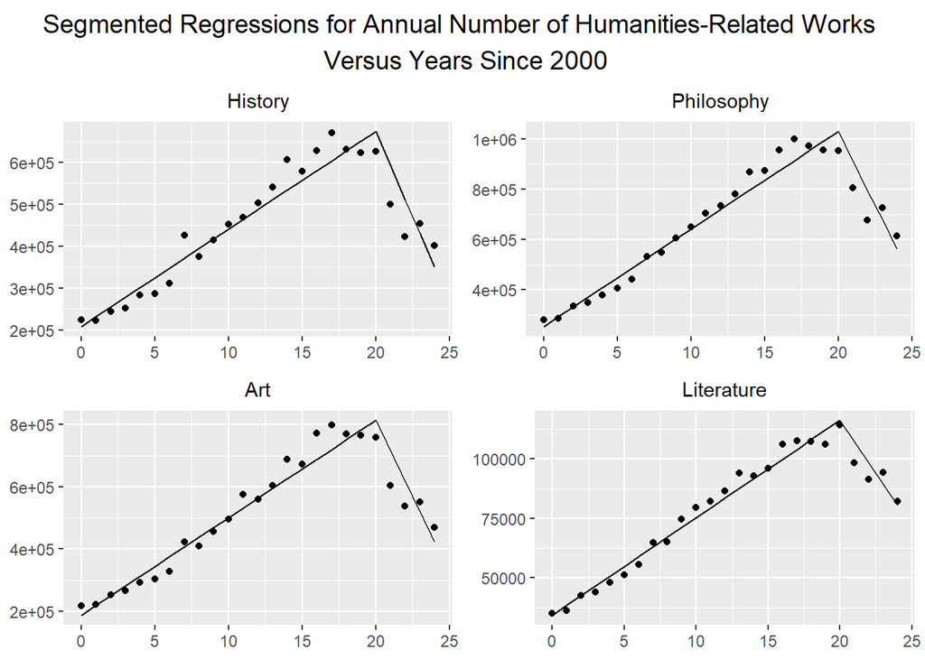

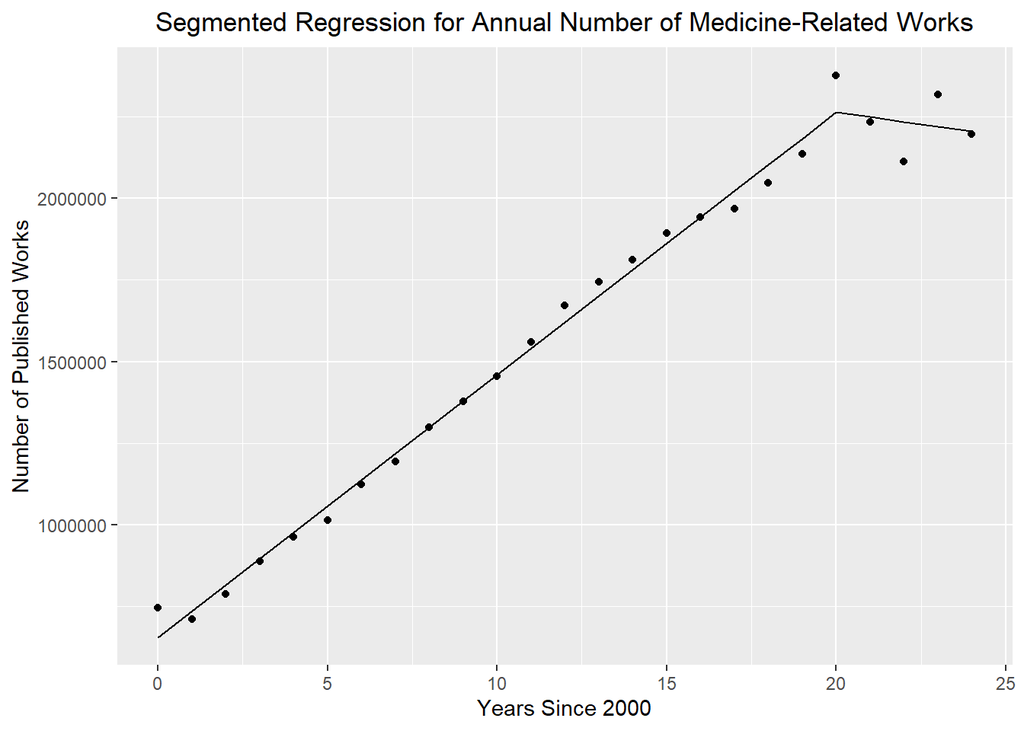

All four fields in the humanities displayed a strong increasing linear trend in annual number of published works from the years 2000 to 2020 and, starting from 2021 onward, decreased linearly at a rate higher than their previous increase.

Medicine too displayed a strong increasing linear trend from the years 2000 to 2020 and started to decrease following 2021, but this rate was much lower than the previous increase, distinguishing itself from the fields in the humanities.

## Extrapolating Trends

The following table reports the predicted number of published works in each field in 2027, as estimated from the segmented linear regressions constructed, along with the corresponding percentage decrease compared to the observed 2020 values:

|  | Predicted Value | Percentage Decrease |
| --- | --- | --- |
| History | 107210 | 83 |
| Philosophy | 211064 | 78 |
| Art | 130651 | 83 |
| Literature | 53389 | 53 |
| Medicine | 2161280 | 9 |

These percentage decreases reveal that medicine experienced, and is projected to experience, a relatively smaller decline in the annual number of published works compared to the four fields in the humanities.

It is important to note that these extrapolated values are tentative estimations made under the strong assumption that the current downward trend in the annual number of published works in each field will continue and at the same rate.

## Assessing Model Fit

The following table reports the adjusted $\small r^2$ values for each segmented regression:

|  | Adj. r<sup>2</sup> |
| --- | --- |
| History | 0.9027 |
| Philosophy | 0.9451 |
| Art | 0.9358 |
| Literature | 0.9714 |
| Medicine | 0.9898 |

The high adjusted $\small r^2$ values ($\small r^2>0.9)$ indicated that a large proportion of variation in the annual number of published works each year was explained by the segmented linear regressions constructed. This indicates that the segmented regressions for all five fields provide a good fit to the data.

To test the significance of the supposed structural break point at $\small t=20$, Chow’s test was used.

## Chow’s Test

Chow’s test is a econometric procedure typically used to test the significance of a known structural break point in time series data, or a specific time when the linear regression parameters would be expected to change substantially, such as the onset of the COVID-19 pandemic in 2020. [8] Chow’s test required the data to be split into two groups—data prior to the hypothesized structural break point (years 2000 to 2020) and after it (years 2021 to 2024). The following null and alternative hypotheses were tested:

- $H_0$: There is not a structural break point in the data and a pooled regression (one that does not split the data into two groups) fits the data sufficiently well.
- $H_A$: There is a structural break point in the data. Regression parameters differ significantly between groups and two separate regressions constructed on each group provides a better fit to the data than a singular pooled regression.

Once the data was grouped, three models were constructed:

1. A null model using data from both groups and no presumed structural breakpoint
2. Two segmented regression models separately constructed from the data in each group

The test statistic $\small C$ for Chow’s test was calculated as follows:

$$C=\frac{(RSS_p-(RSS_1+RSS_2))/k}{(RSS_1+RSS_2)/(N_1+N_2-2k)}$$

- $\small RSS_p$: Sum of squared residuals from the pooled (null) model
- $\small RSS_1,RSS_2$: Sum of square residuals from the segmented regression
- $\small k$: Number of parameters in each regression
- $\small N_1,N_2$: Number of data points used to construct each segmented regression

Where $\small C$ follows an F-distribution with $\small k$ and $\small N_1+N_2-2k$ degrees of freedom.

Using the previously constructed segmented regressions for each field, the following test statistics and p-values were obtained:

|  | Test Statistic | P Value |
| --- | --- | --- |
| History | 42.87 | < 0.001 |
| Philosophy | 63.84 | < 0.001 |
| Art | 56.90 | < 0.001 |
| Literature | 77.05 | < 0.001 |
| Medicine | 24.17 | < 0.001 |

The results of Chow’s Test for all five fields were statistically significant at all commonly used alpha levels. This indicated the presence of a structural break point in the data at the year 2020. Therefore, the annual number of published works in each field should be modeled using a segmented regression, with separate linear trends for $\small t\leq20$ and $\small t>20$, rather than a single continuous linear regression.

This indicates that there was a significant shift in research publication trends following the pandemic in 2020; specifically, there was an abrupt decrease in publication output across all five fields but most pronouncedly among the four fields in the humanities. However, typically statistical analyses, including Chow’s test, are unable to confirm or deny that the COVID-19 pandemic *caused* this observed decrease in the annual number of published works for each field and it can only be speculated as such.

# Conclusion

We analyzed the annual number of published works the humanities and medicine on OpenAlex from 2000 to 2024. To accurately represent the broadness of humanities we considered data from four different fields: history, philosophy, art, and literature. We aimed to compare trends in the annual number of published works in medicine and in the humanities, both in a general sense and specifically before and after the pandemic. Our analysis, which consisted of an interrupted time-series analysis using a multiple segmented regressions as well as Chow’s Test, revealed a few key observations and trends:

1. All five fields experienced an increase in the annual number of published works from 2000 to 2020 and an abrupt decrease afterwards, presumably as a result of the COVID-19 pandemic.
2. From 2021 onward, medicine experienced a relatively smaller decline in the annual number of published works compared to the four humanities-related fields.
3. Medicine was the most productive field of research among the five both before and after the pandemic, producing more published works per year, on average, than all four humanities-related fields.
4. Across all five fields, the annual number of published works from 2000 to 2024 was better modeled using a segmented regression with a break point at the year 2020 than a singular continuous linear regression for all five fields.

From the data, it is clear that humanities-related fields receive consistently less research attention and are now experiencing a more pronounced decline in annual number of published works compared to medicine post-pandemic.

Our findings cannot establish that the COVID-19 pandemic directly caused the abrupt decrease in the annual number of humanities-related published works observed after 2020, as external factors were not controlled for. Chow’s Test only establishes the statistical significance of the structural break point at 2020, but it does not provide any insight as to its cause. The observed decrease in the annual number of published works after 2020 may be linked to a multitude of notable events that occurred that year, such as the COVID-19 pandemic, widespread economic struggle as a result of the pandemic, the historic U.S. presidential election, or protests in America. Additionally, the slight decrease in the annual number of medical-related published works observed after 2020 could be linked to the reduced need for studying the SARS-CoV-2 virus following the development of its vaccine. However, these hypotheses as to the abrupt change in published work trends are unable to be statistically verified.

Given the current continuing decrease in the number of published works despite the resolution of COVID-19 and other possible causes previously discussed, there is an evident need to increase support and funding for research in the humanities. We hope our findings can be used to inform such efforts.

## Study Limitations

Our analysis is only based on the number of works published on OpenAlex each year which limits the scope of our findings since it is plausible different trends are observed on other databases such as Google Scholar.

Additionally, as there are still lingering effects socially and economically despite the end of many of the possible causes listed previously, these trends may be temporary and are still subject to change as global events continue to impact academia. Finally, the broad nature of the field of medicine, and the need for replication in scientific fields may account for such a large difference in the number of medicine versus humanities related published works. However, this does not negate from the fact that medicine is disproportionately prioritized and funded compared to the humanities. Additionally, the trends should remain consistent despite any alternative explanation for why the number of published works in medicine is so much greater than the humanities.

## Study Extensibility

Reconducting similar analyses with the inclusion of works from a wider variety of databases could be a topic for future investigation. Additionally, future studies could examine trends over a broader range of years and identify additional potential breakpoints that align with historical events, such as the conclusion of World War II in 1945 or the beginning of the Space Race in 1957.

# Contribution Statement

As a pair, we decided on the topic of our final project and the objectives and methods of our analysis. Elena found the background information and the study cited in the introduction while Anjali got the data from OpenAlex (which was initially obtained via web-scraping but after unexpected database errors on OpenAlex’s end, was retrieved from archives of OpenAlex’s official website). As for the division of labor, Elena mostly completed the preliminary trend evaluations / plots and ITS analysis (segmented regressions and interpretation) while Anjali completed the “Comparing Fields” section and performed and interpreted the results of the Chow’s Tests. As for the writing and making of the final report itself, Elena wrote most of the abstract and conclusion while Anjali completed the study limitations, extensibility, Works Cited sections and made a custom CSS file for the final report. Though most of the work was divided cleanly between the two of us, both of us checked each others’ work along the way.

# Works Cited

[1]

“Impact of the COVID-19 pandemic on publication dynamics and non-COVID-19 research production - BMC Medical Research Methodology — bmcmedresmethodol.biomedcentral.com.” https://bmcmedresmethodol.biomedcentral.com/articles/10.1186/s12874-021-01404-9.

[2]

“Concepts | OpenAlex technical documentation — docs.openalex.org.” https://docs.openalex.org/api-entities/concepts.

[3]

“OpenAlex — History Concept Works.” https://openalex.org/works?filter=concepts.id:c95457728.

[4]

“OpenAlex — Philosophy Concept Works.” https://openalex.org/works?filter=concepts.id:c138885662.

[5]

“OpenAlex — Art Concept Works.” https://openalex.org/works?filter=concepts.id:c142362112.

[6]

“OpenAlex — Literature Concept Works.” https://openalex.org/works?filter=concepts.id:c124952713.

[7]

“OpenAlex — Medicine Concept Works.” https://openalex.org/works?filter=concepts.id:C71924100.

[8]

Z. Bobbitt, “What is a Chow Test? (Explanation & Example) — statology.org.” https://www.statology.org/chow-test/.